# Practice Week 1

Hugo van den Belt

2024-12-14

## R Plotting Setup Notes

Basic visualization setup in R using two key libraries: - `ggplot2`: Main graphics package for creating plots - `kableExtra`: Package for enhanced table formatting in documents

The command `theme_set(theme_gray(15))` sets default plot styling with gray background and 15pt font. Other useful themes include `theme_minimal()`, `theme_bw()`, `theme_classic()`.

**Note: Include `{r plots_and_figures, include=FALSE}` at start of code chunk to run setup without showing code in final document.**

## viewing DataFrames

reading a flat file

```r
CEO_Diary <- read.csv("/Users/hugovandenbelt/Documents/GitHub/GROUP_ASSIGNMENT/survey_response_data.csv")
```

head item (4 rows)

```r
head(CEO_Diary, 4)
```

```
##    id finance mkting production strategy hr bunits other admin board chairman
## 1 607       0      1          0        0  0      0     0     0     0        0
## 2 607       0      1          0        0  0      0     0     0     0        0
## 3 607       0      1          0        0  0      0     0     0     0        0
## 4 607       0      1          0        0  0      0     0     0     0        0
##   compliance coo cao it legal retail groupcom clients suppliers banks investors
## 1          0   0   0  0     0      0        0       1         0     0         0
## 2          0   0   0  0     0      0        0       1         0     0         0
## 3          0   0   0  0     0      0        0       1         0     0         0
## 4          0   0   0  0     0      0        0       1         0     0         0
##   lawyers consultants politicians govoff journalists unions compts others
## 1       0           0           0      0           0      0      0      0
## 2       0           0           0      0           0      0      0      0
## 3       0           0           0      0           0      0      0      0
## 4       0           0           0      0           0      0      0      0
##   dealers associations pemployee ins out n_functions    type      level1
## 1       0            0         0   1   1           2 meeting interacting
## 2       0            0         0   1   1           2 meeting interacting
## 3       0            0         0   1   1           2 meeting interacting
## 4       0            0         0   1   1           2 meeting interacting
##   F_duration F_planned F_participants
## 1        1hr   planned   two_plus_ppl
## 2        1hr   planned   two_plus_ppl
## 3        1hr   planned   two_plus_ppl
## 4        1hr   planned   two_plus_ppl
##                                                         all_combined
## 1 interacting__meeting__1hr__planned__two_plus_pplzzzzmkting_clients
## 2 interacting__meeting__1hr__planned__two_plus_pplzzzzmkting_clients
## 3 interacting__meeting__1hr__planned__two_plus_pplzzzzmkting_clients
## 4 interacting__meeting__1hr__planned__two_plus_pplzzzzmkting_clients
```

can also tail

```r
tail(CEO_Diary, 10)
```

```
##          id finance mkting production strategy hr bunits other admin board
## 225712 1114      NA     NA         NA       NA NA     NA    NA    NA    NA
## 225713 1114      NA     NA         NA       NA NA     NA    NA    NA    NA
## 225714 1114      NA     NA         NA       NA NA     NA    NA    NA    NA
## 225715 1114      NA     NA         NA       NA NA     NA    NA    NA    NA
## 225716 1114      NA     NA         NA       NA NA     NA    NA    NA    NA
## 225717 1114      NA     NA         NA       NA NA     NA    NA    NA    NA
## 225718 1114      NA     NA         NA       NA NA     NA    NA    NA    NA
## 225719 1114      NA     NA         NA       NA NA     NA    NA    NA    NA
## 225720 1114      NA     NA         NA       NA NA     NA    NA    NA    NA
## 225721 1114      NA     NA         NA       NA NA     NA    NA    NA    NA
##        chairman compliance coo cao it legal retail groupcom clients suppliers
## 225712       NA         NA  NA  NA NA    NA     NA       NA      NA        NA
## 225713       NA         NA  NA  NA NA    NA     NA       NA      NA        NA
## 225714       NA         NA  NA  NA NA    NA     NA       NA      NA        NA
```

[output cut: 51 more lines]

## Subsetting

You can subset a df very easily using square brackets, with the input `[rows, columns]`

```r
CEO_Diary[1:10,c(1:5,37, 39:42)] # Shows rows 1 through 10, and colums 1 through 5, 37, and 39 through 42
```

```
##     id finance mkting production strategy    type F_duration F_planned
## 1  607       0      1          0        0 meeting        1hr   planned
## 2  607       0      1          0        0 meeting        1hr   planned
## 3  607       0      1          0        0 meeting        1hr   planned
## 4  607       0      1          0        0 meeting        1hr   planned
## 5  607       0      1          1        0 meeting        1hr unplanned
## 6  607       0      1          1        0 meeting        1hr unplanned
## 7  607       0      1          1        0 meeting        1hr unplanned
## 8  607       0      1          1        0 meeting        1hr unplanned
## 9  607      NA     NA         NA       NA   email    1hrplus   planned
## 10 607      NA     NA         NA       NA   email    1hrplus   planned
##    F_participants
## 1    two_plus_ppl
## 2    two_plus_ppl
## 3    two_plus_ppl
```

[output cut: 18 more lines]

`:` slices (includes lower and upper limit)

The `apply()` function lets you apply a function across a data frame or matrix, either by rows or columns. It takes three main arguments:

1. The data frame/matrix (in this case, CEO_Diary)
2. A number indicating direction (1 for rows, 2 for columns)
3. The function to apply (in this case, class)

with our df this would look like:

```r
apply(CEO_Diary, 2, class)
```

```
##             id        finance         mkting     production       strategy
##    "character"    "character"    "character"    "character"    "character"
##             hr         bunits          other          admin          board
##    "character"    "character"    "character"    "character"    "character"
##       chairman     compliance            coo            cao             it
##    "character"    "character"    "character"    "character"    "character"
##          legal         retail       groupcom        clients      suppliers
##    "character"    "character"    "character"    "character"    "character"
##          banks      investors        lawyers    consultants    politicians
##    "character"    "character"    "character"    "character"    "character"
##         govoff    journalists         unions         compts         others
##    "character"    "character"    "character"    "character"    "character"
##        dealers   associations      pemployee            ins            out
##    "character"    "character"    "character"    "character"    "character"
##    n_functions           type         level1     F_duration      F_planned
##    "character"    "character"    "character"    "character"    "character"
## F_participants   all_combined
##    "character"    "character"
```

and with a simpler df it could look like this:

```r
# sample data frame
sample_df <- data.frame(
    name = c("Alice", "Bob"),
    age = c(25, 30),
    active = c(TRUE, FALSE)
)

# Apply class function to each column
apply(sample_df, 2, class)
```

```
##        name         age      active
## "character" "character" "character"
```

For some reason it identifies all columns as characters. Why?

Apparently, when we apply the `apply()` function, R converts our df into a matrix, but in a matrix every element must be of the same type. We can use the `sapply()` function to see the classes directly:

```r
sapply(sample_df, class)
```

```
##        name         age      active
## "character"   "numeric"   "logical"
```

```r
sapply(CEO_Diary, class)
```

```
##             id        finance         mkting     production       strategy
##      "integer"      "numeric"      "numeric"      "numeric"      "numeric"
##             hr         bunits          other          admin          board
##      "numeric"      "numeric"      "numeric"      "numeric"      "numeric"
##       chairman     compliance            coo            cao             it
##      "numeric"      "numeric"      "numeric"      "numeric"      "numeric"
##          legal         retail       groupcom        clients      suppliers
##      "numeric"      "numeric"      "numeric"      "numeric"      "numeric"
##          banks      investors        lawyers    consultants    politicians
##      "numeric"      "numeric"      "numeric"      "numeric"      "numeric"
##         govoff    journalists         unions         compts         others
##      "numeric"      "numeric"      "numeric"      "numeric"      "numeric"
##        dealers   associations      pemployee            ins            out
##      "numeric"      "numeric"      "numeric"      "numeric"      "numeric"
##    n_functions           type         level1     F_duration      F_planned
##      "integer"    "character"    "character"    "character"    "character"
## F_participants   all_combined
##    "character"    "character"
```

## Some statistics

we can get the number of rows

```r
nrow(CEO_Diary)
```

```
## [1] 225721
```

let me guess, we can get the number of columns by doing ncolumn or something

```r
ncol(CEO_Diary) # indeed
```

```
## [1] 42
```

We can get summary statistics

```r
summary(CEO_Diary[1:10]) # Columns 1 through 10
```

```
##        id            finance          mkting        production
##  Min.   :   1.0   Min.   :0.00    Min.   :0.00    Min.   :0.00
##  1st Qu.: 269.0   1st Qu.:0.00    1st Qu.:0.00    1st Qu.:0.00
##  Median : 521.0   Median :0.00    Median :0.00    Median :0.00
##  Mean   : 543.3   Mean   :0.17    Mean   :0.23    Mean   :0.35
##  3rd Qu.: 823.0   3rd Qu.:0.00    3rd Qu.:0.00    3rd Qu.:1.00
##  Max.   :1115.0   Max.   :1.00    Max.   :1.00    Max.   :1.00
##                   NA's   :98406   NA's   :98371   NA's   :98408
##     strategy           hr            bunits          other
##  Min.   :0.00    Min.   :0.00    Min.   :0.00    Min.   :0.00
##  1st Qu.:0.00    1st Qu.:0.00    1st Qu.:0.00    1st Qu.:0.00
##  Median :0.00    Median :0.00    Median :0.00    Median :0.00
##  Mean   :0.02    Mean   :0.08    Mean   :0.06    Mean   :0.05
##  3rd Qu.:0.00    3rd Qu.:0.00    3rd Qu.:0.00    3rd Qu.:0.00
##  Max.   :1.00    Max.   :1.00    Max.   :1.00    Max.   :1.00
##  NA's   :98414   NA's   :98412   NA's   :98414   NA's   :98316
##      admin           board
##  Min.   :0.00    Min.   :0.00
##  1st Qu.:0.00    1st Qu.:0.00
##  Median :0.00    Median :0.00
##  Mean   :0.04    Mean   :0.04
##  3rd Qu.:0.00    3rd Qu.:0.00
##  Max.   :1.00    Max.   :1.00
##  NA's   :98410   NA's   :98414
```

Create a frequency table of a certain column

```r
table(CEO_Diary$finance)
```

```
##
##      0      1
## 105601  21714
```

```r
table(CEO_Diary$n_functions)
```

```
##
##      0      1      2      3      4      5      6      7      8      9     11
## 100301  77182  27512  10985   5097   2735   1119    455    155    118     16
##     12     17
##     28     18
```

The `$` operator selects columns

Building on this, we can view proportions

```r
prop.table(table(CEO_Diary$type))
```

```
##
##       business_meal     conference_call               email             meeting
##        0.0419057155        0.0185317272        0.0526313458        0.4170413918
##               other     personal_family          phone_call        public_event
##        0.0002746754        0.0970002791        0.0313440043        0.0129053123
##          site_visit          travelling    video_conference       working_alone
##        0.0335724190        0.0839531989        0.0030967433        0.2008497216
## workrelated_leisure
##        0.0068934658
```

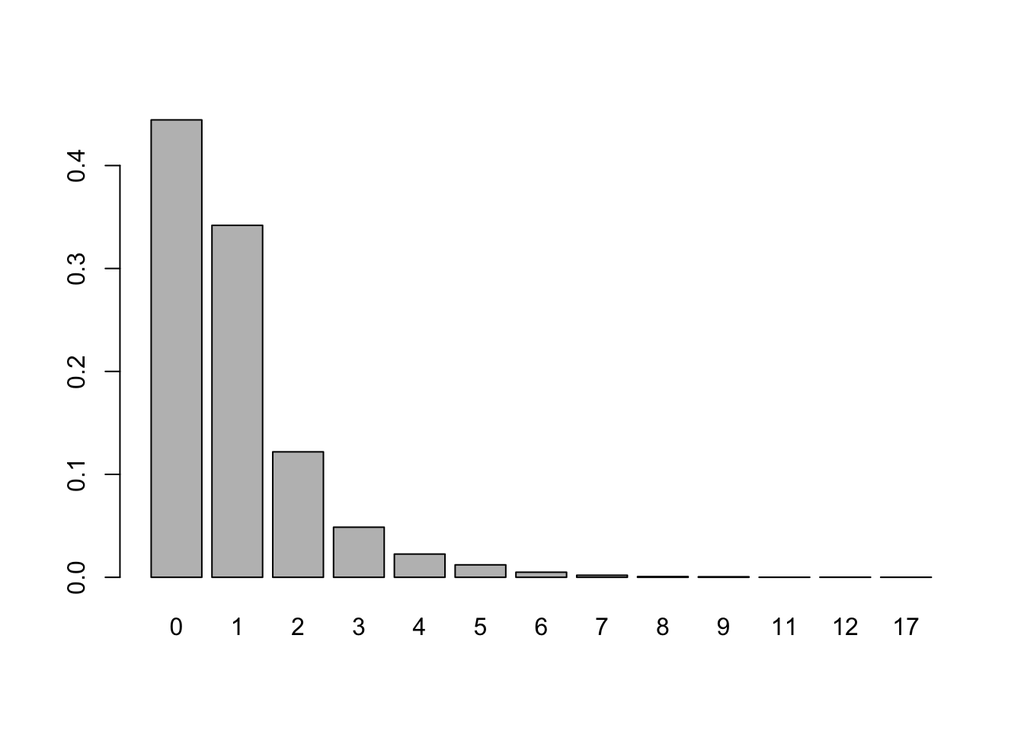

```r
barplot(prop.table(table(CEO_Diary$n_functions)))
```

## MODELING TIME

we can fit a linear model with chosen variables

```r
fit <- glm(strategy ~ consultants + politicians, data=CEO_Diary)
summary(fit)
```

```
##
## Call:
## glm(formula = strategy ~ consultants + politicians, data = CEO_Diary)
##
## Coefficients:
##               Estimate Std. Error t value Pr(>|t|)
## (Intercept)  0.0239291  0.0004396  54.433  < 2e-16 ***
## consultants  0.0113590  0.0023339   4.867 1.13e-06 ***
## politicians -0.0241179  0.0053095  -4.542 5.57e-06 ***
## ---
## Signif. codes:  0 '***' 0.001 '**' 0.01 '*' 0.05 '.' 0.1 ' ' 1
##
## (Dispersion parameter for gaussian family taken to be 0.02357801)
##
##     Null deviance: 3002.6  on 127306  degrees of freedom
## Residual deviance: 3001.6  on 127304  degrees of freedom
##   (98414 observations deleted due to missingness)
## AIC: -115789
##
## Number of Fisher Scoring iterations: 2
```

The presence of consultants *increases* the probability of the meeting being about strategy. The presence of politicians *decreases* the probability of the meeting being about strategy.

We can add as many independents as we’d like

```r
fit_all <- glm(strategy ~ consultants + politicians + journalists + unions + investors + lawyers, data=CEO_Diary)

summary(fit_all)
```

```
##
## Call:
## glm(formula = strategy ~ consultants + politicians + journalists +
##     unions + investors + lawyers, data = CEO_Diary)
##
## Coefficients:
##               Estimate Std. Error t value Pr(>|t|)
## (Intercept)  0.0244266  0.0004468  54.667  < 2e-16 ***
## consultants  0.0113637  0.0023354   4.866 1.14e-06 ***
## politicians -0.0138297  0.0056825  -2.434 0.014945 *
## journalists -0.0204696  0.0047038  -4.352 1.35e-05 ***
## unions      -0.0228020  0.0066559  -3.426 0.000613 ***
## investors    0.0024517  0.0036303   0.675 0.499452
## lawyers     -0.0214265  0.0036289  -5.904 3.55e-09 ***
## ---
## Signif. codes:  0 '***' 0.001 '**' 0.01 '*' 0.05 '.' 0.1 ' ' 1
##
## (Dispersion parameter for gaussian family taken to be 0.02356653)
##
##     Null deviance: 3002.6  on 127306  degrees of freedom
## Residual deviance: 3000.0  on 127300  degrees of freedom
##   (98414 observations deleted due to missingness)
## AIC: -115847
##
## Number of Fisher Scoring iterations: 2
```